# Retail Sales — Data Visualization Report

**Task 3: Meaningful Visualizations with Matplotlib, Seaborn & Plotly**

Dataset: synthetic Superstore-style retail sales data (2,200 orders, Jan 2023 – Dec 2024) covering Category, Sub-Category, Region, Segment, Sales, Profit, Quantity and Discount.

```python
import pandas as pd
import numpy as np
import matplotlib.pyplot as plt
import seaborn as sns
import plotly.express as px
import plotly.graph_objects as go
from plotly.subplots import make_subplots

sns.set_theme(style="whitegrid")
PALETTE = sns.color_palette("viridis", 8)
plt.rcParams["figure.dpi"] = 110
plt.rcParams["font.size"] = 11

df = pd.read_csv("data/sales_data.csv", parse_dates=["Order_Date"])
df["Month"] = df["Order_Date"].dt.to_period("M").dt.to_timestamp()
df.head()
```

|  | Order_ID | Order_Date | Category | Sub_Category | Region | Segment | Sales | Quantity | Profit | Discount | Month |
| --- | --- | --- | --- | --- | --- | --- | --- | --- | --- | --- | --- |
| 0 | ORD-11337 | 2023-01-01 | Office Supplies | Paper | West | Home Office | 302.75 | 7 | 88.01 | 0.2 | 2023-01-01 |
| 1 | ORD-11658 | 2023-01-01 | Office Supplies | Art | East | Consumer | 43.39 | 1 | 12.00 | 0.1 | 2023-01-01 |
| 2 | ORD-11251 | 2023-01-01 | Technology | Accessories | North | Home Office | 2108.64 | 6 | 289.50 | 0.0 | 2023-01-01 |
| 3 | ORD-10170 | 2023-01-02 | Office Supplies | Paper | South | Corporate | 61.23 | 3 | 7.45 | 0.0 | 2023-01-01 |
| 4 | ORD-11456 | 2023-01-02 | Technology | Accessories | East | Consumer | 856.41 | 3 | 138.20 | 0.0 | 2023-01-01 |

## 1. Data Overview

```python
print(f"Rows: {len(df):,}   Columns: {df.shape[1]}")
print(f"Date range: {df['Order_Date'].min().date()} to {df['Order_Date'].max().date()}")
df.describe(include="all").T
```

```
Rows: 2,200   Columns: 11
Date range: 2023-01-01 to 2024-12-31
```

|  | count | unique | top | freq | mean | min | 25% | 50% | 75% | max | std |
| --- | --- | --- | --- | --- | --- | --- | --- | --- | --- | --- | --- |
| Order_ID | 2200 | 2200 | ORD-11337 | 1 | NaN | NaN | NaN | NaN | NaN | NaN | NaN |
| Order_Date | 2200 | NaN | NaN | NaN | 2024-01-02 08:40:21.818181 | 2023-01-01 00:00:00 | 2023-07-02 00:00:00 | 2024-01-05 00:00:00 | 2024-07-07 00:00:00 | 2024-12-31 00:00:00 | NaN |
| Category | 2200 | 3 | Office Supplies | 1010 | NaN | NaN | NaN | NaN | NaN | NaN | NaN |
| Sub_Category | 2200 | 13 | Paper | 213 | NaN | NaN | NaN | NaN | NaN | NaN | NaN |
| Region | 2200 | 4 | East | 566 | NaN | NaN | NaN | NaN | NaN | NaN | NaN |
| Segment | 2200 | 3 | Consumer | 1091 | NaN | NaN | NaN | NaN | NaN | NaN | NaN |
| Sales | 2200.0 | NaN | NaN | NaN | 786.644527 | 1.4 | 147.15 | 385.47 | 1110.965 | 6660.74 | 939.257378 |
| Quantity | 2200.0 | NaN | NaN | NaN | 3.964545 | 1.0 | 2.0 | 4.0 | 6.0 | 7.0 | 1.997182 |
| Profit | 2200.0 | NaN | NaN | NaN | 108.629605 | -613.11 | 11.4625 | 41.84 | 123.28 | 2445.04 | 209.974234 |
| Discount | 2200.0 | NaN | NaN | NaN | 0.094932 | 0.0 | 0.0 | 0.1 | 0.15 | 0.3 | 0.094748 |
| Month | 2200 | NaN | NaN | NaN | 2023-12-18 09:32:43.636363 | 2023-01-01 00:00:00 | 2023-07-01 00:00:00 | 2024-01-01 00:00:00 | 2024-07-01 00:00:00 | 2024-12-01 00:00:00 | NaN |

## 2. Bar Chart — Total Sales & Profit by Category

Compares revenue against profit across the three product categories. Grouped bars make the category-level profit gap immediately visible (Furniture's thin margin vs Technology's strong one).

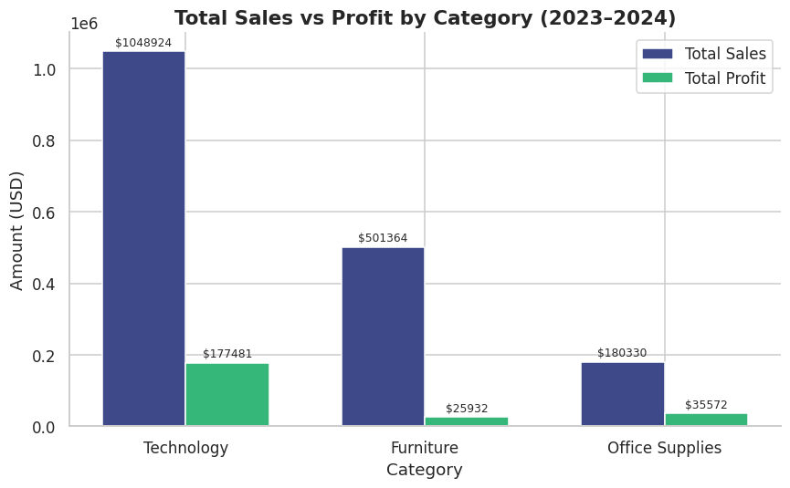

```python
cat_summary = df.groupby("Category")[["Sales", "Profit"]].sum().sort_values("Sales", ascending=False)

fig, ax = plt.subplots(figsize=(8, 5))
x = np.arange(len(cat_summary))
width = 0.35

bars1 = ax.bar(x - width/2, cat_summary["Sales"], width, label="Total Sales", color=PALETTE[1])
bars2 = ax.bar(x + width/2, cat_summary["Profit"], width, label="Total Profit", color=PALETTE[5])

ax.set_title("Total Sales vs Profit by Category (2023–2024)", fontsize=14, fontweight="bold")
ax.set_xlabel("Category")
ax.set_ylabel("Amount (USD)")
ax.set_xticks(x)
ax.set_xticklabels(cat_summary.index)
ax.legend()
ax.bar_label(bars1, fmt="$%.0f", fontsize=8, padding=2)
ax.bar_label(bars2, fmt="$%.0f", fontsize=8, padding=2)
sns.despine()
plt.tight_layout()
plt.savefig("outputs/01_bar_sales_profit_by_category.png", bbox_inches="tight")
plt.show()
```

## 3. Line Chart — Monthly Sales Trend

Tracks how total monthly sales evolved across the two-year window, split by category, to surface seasonality (e.g. holiday-season spikes).

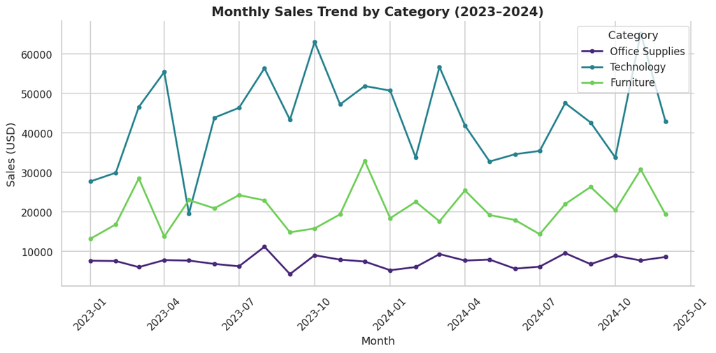

```python
monthly = df.groupby(["Month", "Category"])["Sales"].sum().reset_index()

fig, ax = plt.subplots(figsize=(11, 5.5))
for cat, color in zip(df["Category"].unique(), PALETTE[::3]):
    sub = monthly[monthly["Category"] == cat]
    ax.plot(sub["Month"], sub["Sales"], marker="o", markersize=4, linewidth=2, label=cat, color=color)

ax.set_title("Monthly Sales Trend by Category (2023–2024)", fontsize=14, fontweight="bold")
ax.set_xlabel("Month")
ax.set_ylabel("Sales (USD)")
ax.legend(title="Category")
ax.tick_params(axis="x", rotation=45)
sns.despine()
plt.tight_layout()
plt.savefig("outputs/02_line_monthly_sales_trend.png", bbox_inches="tight")
plt.show()
```

## 4. Pie Chart — Sales Share by Region

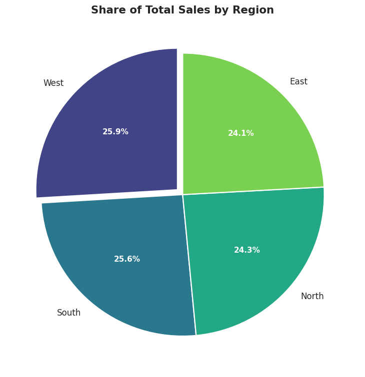

```python
region_sales = df.groupby("Region")["Sales"].sum().sort_values(ascending=False)

fig, ax = plt.subplots(figsize=(7, 7))
colors = sns.color_palette("viridis", len(region_sales))
wedges, texts, autotexts = ax.pie(
    region_sales,
    labels=region_sales.index,
    autopct="%1.1f%%",
    startangle=90,
    colors=colors,
    explode=[0.05 if v == region_sales.max() else 0 for v in region_sales],
    wedgeprops={"edgecolor": "white", "linewidth": 1.5},
)
plt.setp(autotexts, size=10, weight="bold", color="white")
ax.set_title("Share of Total Sales by Region", fontsize=14, fontweight="bold")
plt.tight_layout()
plt.savefig("outputs/03_pie_sales_by_region.png", bbox_inches="tight")
plt.show()
```

**Insight:** Sales are fairly evenly split across the four regions, with the leading region only a few points ahead of the rest — there's no single dominant market, so regional strategy should focus on lifting the weakest region rather than over-indexing on the top one.

## 5. Histogram — Distribution of Profit per Order

Shows how profit is distributed across all orders, including how often orders are unprofitable.

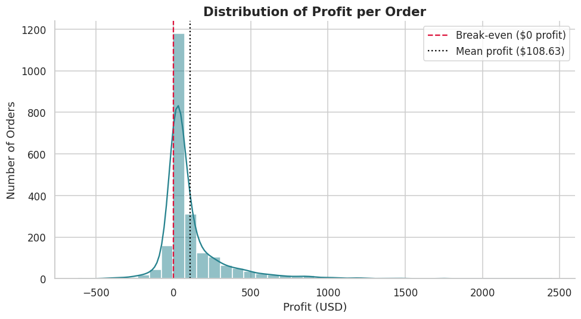

```python
fig, ax = plt.subplots(figsize=(9, 5))
sns.histplot(df["Profit"], bins=40, kde=True, color=PALETTE[3], edgecolor="white", ax=ax)
ax.axvline(0, color="crimson", linestyle="--", linewidth=1.5, label="Break-even ($0 profit)")
ax.axvline(df["Profit"].mean(), color="black", linestyle=":", linewidth=1.5,
           label=f"Mean profit (${df['Profit'].mean():.2f})")

ax.set_title("Distribution of Profit per Order", fontsize=14, fontweight="bold")
ax.set_xlabel("Profit (USD)")
ax.set_ylabel("Number of Orders")
ax.legend()
sns.despine()
plt.tight_layout()
plt.savefig("outputs/04_histogram_profit_distribution.png", bbox_inches="tight")
plt.show()
```

```python
loss_pct = (df["Profit"] < 0).mean() * 100
print(f"{loss_pct:.1f}% of orders are sold at a loss.")
```

```
11.1% of orders are sold at a loss.
```

**Insight:** Profit is roughly bell-shaped but right-skewed, with a meaningful cluster of loss-making orders sitting left of the break-even line — largely driven by heavily discounted Furniture orders. Tightening discount rules on low-margin categories would shift this distribution rightward.

## 6. Scatter Plot — Sales vs Profit by Category

Each point is one order; color encodes category and size encodes quantity, to see whether higher-value orders reliably convert into higher profit.

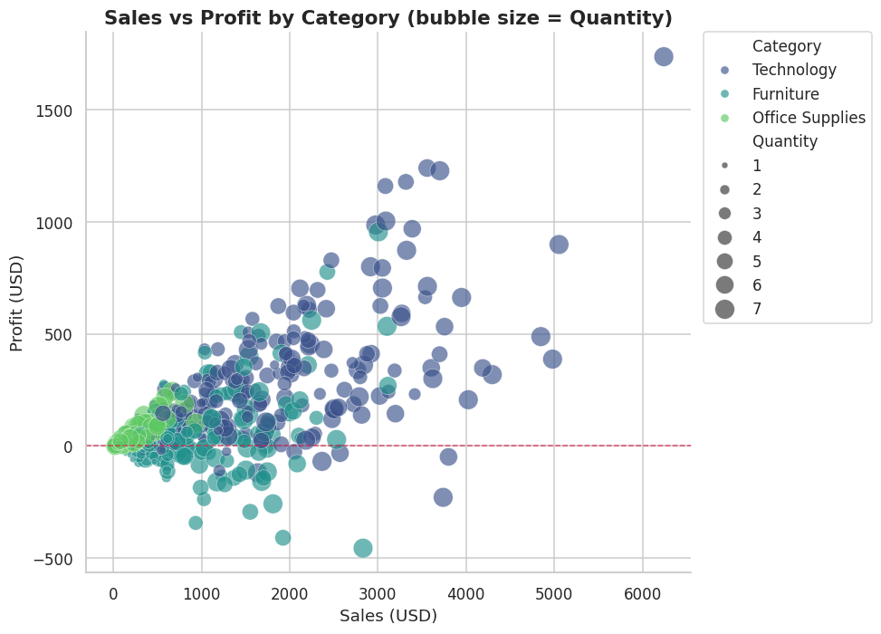

```python
fig, ax = plt.subplots(figsize=(9, 6.5))
sample = df.sample(min(800, len(df)), random_state=1)  # sample for readability

sns.scatterplot(
    data=sample, x="Sales", y="Profit", hue="Category", size="Quantity",
    sizes=(20, 200), alpha=0.65, palette="viridis", ax=ax
)
ax.axhline(0, color="crimson", linestyle="--", linewidth=1, alpha=0.7)
ax.set_title("Sales vs Profit by Category (bubble size = Quantity)", fontsize=14, fontweight="bold")
ax.set_xlabel("Sales (USD)")
ax.set_ylabel("Profit (USD)")
ax.legend(bbox_to_anchor=(1.02, 1), loc="upper left", borderaxespad=0)
sns.despine()
plt.tight_layout()
plt.savefig("outputs/05_scatter_sales_vs_profit.png", bbox_inches="tight")
plt.show()
```

**Insight:** Technology orders (upper band) scale profit with sales fairly consistently. Furniture orders cluster closer to the zero line and dip below it more often even at high sales values — confirming that high revenue alone doesn't guarantee high profit in that category.

## 7. Bonus — Interactive Dashboard (Plotly)

Power BI / Tableau aren't available in this environment, so this section builds an equivalent **interactive HTML dashboard** with Plotly: hover tooltips, zoom, and filterable legends, exported as a standalone file you can open in any browser (no software needed) or embed elsewhere.

```python
fig = make_subplots(
    rows=2, cols=2,
    subplot_titles=("Monthly Sales Trend", "Sales by Category", "Profit Distribution", "Region Sales Share"),
    specs=[[{"type": "xy"}, {"type": "xy"}], [{"type": "xy"}, {"type": "domain"}]],
)

monthly_total = df.groupby("Month")["Sales"].sum().reset_index()
fig.add_trace(go.Scatter(x=monthly_total["Month"], y=monthly_total["Sales"],
                          mode="lines+markers", name="Sales", line=dict(color="#440154")), row=1, col=1)

cat_sales = df.groupby("Category")["Sales"].sum().reset_index()
fig.add_trace(go.Bar(x=cat_sales["Category"], y=cat_sales["Sales"], name="Sales by Category",
                      marker_color=["#440154", "#31688e", "#35b779"]), row=1, col=2)

fig.add_trace(go.Histogram(x=df["Profit"], nbinsx=40, name="Profit", marker_color="#31688e"), row=2, col=1)

reg_sales = df.groupby("Region")["Sales"].sum().reset_index()
fig.add_trace(go.Pie(labels=reg_sales["Region"], values=reg_sales["Sales"], name="Region"), row=2, col=2)

fig.update_layout(
    height=800, width=1100, showlegend=False,
    title_text="Retail Sales Dashboard (2023–2024)", title_font_size=20,
    template="plotly_white",
)
fig.write_html("outputs/06_interactive_dashboard.html")
fig.show()
```

**Files produced:** 5 static PNG charts in `outputs/` + 1 interactive HTML dashboard (`outputs/06_interactive_dashboard.html`) for the bonus requirement.